# Project 1 : Test a Perceptual Phenomenon

Isabel María Villalba Jiménez

6 de diciembre de 2016

# Project Instructions

## Background Information

In a Stroop task, participants are presented with a list of words, with each word displayed in a color of ink. The participant’s task is to say out loud the color of the ink in which the word is printed. The task has two conditions: a congruent words condition, and an incongruent words condition. In the congruent words condition, the words being displayed are color words whose names match the colors in which they are printed: for example RED , BLUE . In the incongruent words condition, the words displayed are color words whose names do not match the colors in which they are printed: for example PURPLE, ORANGE. In each case, we measure the time it takes to name the ink colors in equally-sized lists. Each participant will go through and record a time from each condition.

## Questions For Investigation

As a general note, be sure to keep a record of any resources that you use or refer to in the creation of your project. You will need to report your sources as part of the project submission.

1. What is our independent variable? What is our dependent variable?

> The **independent variables** are the conditions (congruent and incongruent), and the **dependent variable** is the time to name the ink color in equally-sized lits.
2. What is an appropriate set of hypotheses for this task? What kind of statistical test do you expect to perform? Justify your choices.

> The null hypothesis will be that congruent and incongruent conditions’ times will be the same, that people identify equally fast the color in both conditions. The alternative hypothesis will be that the mean is changed.

Now it’s your chance to try out the Stroop task for yourself. Go to this [link](https://faculty.washington.edu/chudler/java/ready.html), which has a Java-based applet for performing the Stroop task. Record the times that you received on the task (you do not need to submit your times to the site.) Now, download this [dataset](https://drive.google.com/file/d/0B9Yf01UaIbUgQXpYb2NhZ29yX1U/view?usp=sharing) which contains results from a number of participants in the task. Each row of the dataset contains the performance for one participant, with the first number their results on the congruent task and the second number their performance on the incongruent task.

3. Report some descriptive statistics regarding this dataset. Include at least one measure of central tendency and at least one measure of variability.

   ```r
   library(reshape2)
   df <- read.csv("~/Git/data-analyst-nanodegree/P1-test-perceptual-phenomenon/stroopdata.csv",
       sep = ",", header = TRUE)

   # Total population
   mu_total <- mean(melt(df)$value)
   s_total <- sd(melt(df)$value)
   sprintf("Total mean is %.3f s, standard deviation is %.3f s",
       mu_total, s_total)

   # Differential case
   df.diff <- df$Incongruent - df$Congruent

   mu_diff <- mean(df.diff)
   s_diff <- sd(df.diff)
   sprintf("Mean of differences is %.3f s, standard deviation is %.3f s",
       mu_diff, s_diff)

   # Congruent
   mu_c <- mean(df$Congruent)
   s_c <- sd(df$Congruent)

   sprintf("Congruent mean is %.3f s, standard deviation is %.3f s",
       mu_c, s_c)

   # Inconruent
   mu_i <- mean(df$Incongruent)
   s_i <- sd(df$Incongruent)

   sprintf("Incogruent mean is %.3f s, standard deviation is %.3f s",
       mu_i, s_i)
   ```

> The mean for the **both conditions** is 18.034 s with a standard deviation of 5.802 s.

> The mean for the **congruent condition** is 14.051 s with a standard deviation of 3.559 s.

> The mean for the **incongruent condition** is 22.016 s with a standard deviation of 4.797 s.
4. Provide one or two visualizations that show the distribution of the sample data. Write one or two sentences noting what you observe about the plot or plots.

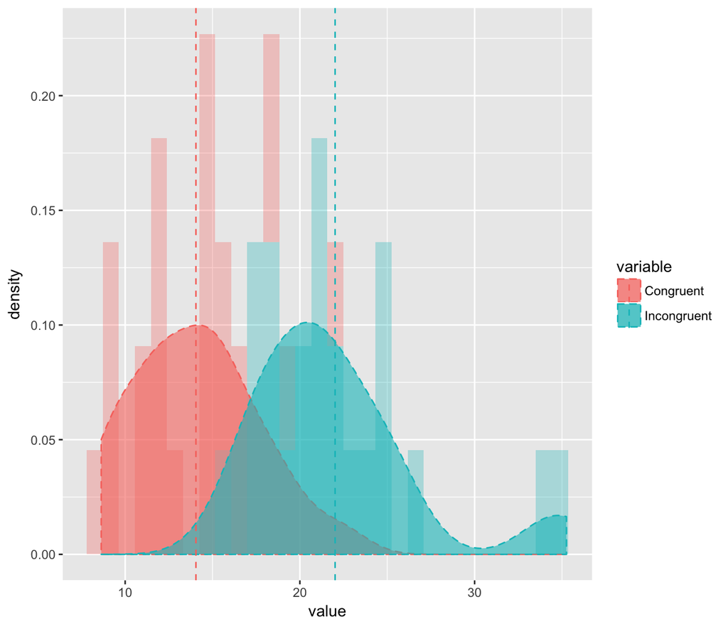

   Figure 1: Data distribution

   ```r
   library(ggplot2)
   library(reshape2)

   library(plyr)
   mu <- ddply(melt(df), "variable", summarise, grp.mean = mean(value))

   p <- ggplot(melt(df), aes(x = value, fill = variable)) +
       geom_histogram(aes(y = ..density..), alpha = 0.3) +
       geom_density(aes(x = value, color = variable), alpha = 0.6,
           linetype = "dashed")

   # Add mean lines
   p + geom_vline(data = mu, aes(xintercept = grp.mean, color = variable),
       linetype = "dashed", alpha = 1)
   ```

   ```r
   df_diff <- data.frame(df.diff)
   n <- length(df_diff)
   df <- n - 1
   SE <- s_diff/sqrt(n)
   t <- mu_diff/SE
   ```